# 기초통계학

#### Instructor: 장재호 (jaehochang@konkuk.ac.kr)

## 1. 통계학의 분류

### 1.1. 기술통계(Descriptive Statistics)

기술통계는 말 그대로 자료의 특성(characteristic)을 기술하는 성격을 지닌 통계량(statistics)를 말한다.

- 빈도(Frequency)
- 평균(Mean)
- 중위수(Median)
- 표준편차(Standard Deviation)
- 분산(Variance)
- 왜도(Skewness)
- 첨도(Kurtosis)

### 1.1. 확률변수

정의: 확률변수는 **사건**을 **숫자**로 대응시키는 함수이다.

예) 동전을 던져서 본 윗면이 \(X\)면? \[ X:\{앞면, 뒷면\}\rightarrow \{0, 1\} \] \(X(\{앞면\})=1\), \(X(\{뒷면\})=0\)

예) 축구선수가 슛을 찼을때 결과가 \(X\)면? \[ X:\{노골, 골\}\rightarrow \{0, 1\} \] \(X(\{노골\})=0\), \(X(\{골\})=1\)

#### 예제 1.1.1.

\(X=\,\)A, B, C, D, E 총 5명의 사람중 대회에 참여할 사람의 수

\[X:\{\{\emptyset\},\{A\},\{B\},\{C\},\{D\},\{E\},\{A,B\},\{A,C\},\cdots,\{A,B,C,D,E\}\}\rightarrow\{0,1,2,3,4,5\}\]

\(X(\{\emptyset\})=0\)

\(X(\{A\})=X(\{B\})=X(\{C\})=X(\{D\})=X(\{E\})=1\)

\(X(\{A,B\})=X(\{B,C\})=\cdots=X(\{D,E\})=2\)

\(X(\{A,B,C\})=X(\{A,B,D\})=\cdots=X(\{C,D,E\})=3\)

\(X(\{A,B,C,D\})=X(\{A,B,C,E\})=\cdots=X(\{B,C,D,E\})=4\)

\(X(\{A,B,C,D,E\})=5\)

### 1.2. 확률변수의 독립

두 확률변수 \(X, Y\)는 다음을 만족하면 서로 독립이라고 한다.

\[P(X,Y)=P(X)P(Y)\]

#### 예제 1.2.1.

동전을 두 번 던질 때 윗면을 \(X_1, X_2\)라 하자. 앞면을 1, 뒷면을 0이라 하자.

\[ P(X_1=1, X_2=1)=\frac{1}{4}=\frac{1}{2}\times\frac{1}{2}=P(X_1=1)P(X_2=1)\\ P(X_1=1, X_2=0)=\frac{1}{4}=\frac{1}{2}\times\frac{1}{2}=P(X_1=1)P(X_2=0)\\ P(X_1=0, X_2=1)=\frac{1}{4}=\frac{1}{2}\times\frac{1}{2}=P(X_1=0)P(X_2=1)\\ P(X_1=0, X_2=0)=\frac{1}{4}=\frac{1}{2}\times\frac{1}{2}=P(X_1=0)P(X_2=0)\\ \] 따라서 \(X_1, X_2\)는 서로 독립이다.

### 1.3. 확률변수의 기대값

확률변수의 기대값(Expectation)은 다음과 같이 정의된다. 먼저 이산형(discrete) 확률변수 \(X\)의 기대값은 \[E(X):=\sum_x x\cdot p_X(x)\] 여기서 \(p_X(x)\)는 확률변수 \(X\)의 확률질량함수(probability mass function, pmf)라 한다. 연속형(continuous) 확률변수의 \(Y\)의 기대값은 다음과 같이 정의된다. \[E(Y):=\int_y y\cdot f_Y(y)dy\] 여기서 \(f_Y(y)\)는 확률변수 \(Y\)의 확률밀도함수(probability density function, pdf)라 한다.

#### 예제 1.3.1.

확률변수 \(X\)를 주사위를 하나 던질 때 나온 눈이라 하자. 이때 확률변수 \(X\)의 기대값은 \[E(X)=\sum_x x\cdot p_X(x)=1\cdot\frac{1}{6} + \cdots + 6\cdot\frac{1}{6}=\frac{21}{6}=\frac{7}{2}=3.5\] 위 예제에서 보듯이, 기대값은 평균(mean)을 일반화한 개념이라고 볼 수 있다.

#### 예제 1.3.2.

확률변수 \(Y\)가 다음 연속형 확률분포를 따른다고 하자. \[f_Y(y)=y,~0\leq y\leq1\] 이때 \(Y\)의 기대값을 구하면 \[E(Y)=\int_0^1y\cdot ydy=\left.\frac{y^3}{3}\right|_0^1=\frac{1}{3}\]

확률변수의 기대값(Expectation)은 다음과 같은 형태로 일반화(generalize)할 수 있다. \[E[g(X)]:=\sum_x g(x)\cdot p_X(x)\] \[E[g(Y)]:=\int_y g(y)\cdot f_Y(y)dy\] 확률분포의 분산(Variance)는 다음과 같이 계산한다. \[Var(X)=E[\{X-E(X)\}^2]=E(X^2)-E(X)^2\]

### 1.4. 정규분포와 그 성질

정규분포는 연속형 확률분포로서, 다음과 같은 확률밀도함수를 가진다. \[f(x)=\frac{1}{\sqrt{2\pi\sigma^2}}\exp\left\{-\frac{(x-\mu)^2}{2\sigma^2}\right\}\]

여기서 \(x\)는 실수의 어떤 값도 될 수 있으며, 음의 무한대나 양의 무한대도 허용한다. \(\mu,\sigma^2\)는 각각 평균, 분산을 의미한다.

확률변수 \(X\)가 정규분포를 따를 때 다음과 같이 표현한다. \[X\sim\mathcal{N}(\mu,\sigma^2)\] 정규분포는 다음과 같은 형태를 가진다.

[figure not shown]

#### 1.4.1. 정규분포의 성질

확률변수 \(X\)가 평균이 \(\mu\), 분산이 \(\sigma^2\)인 정규분포를 따른다 하자. 이때 다음이 성립한다.

- \(X+a\sim\mathcal{N}(\mu+a,\sigma^2)\), 즉 정규분포는 평행이동이 가능하다.
- \(b\cdot X\sim\mathcal{N}(\mu,b^2\sigma^2)\), 즉 정규분포는 스케일링(scaling)이 가능하다.
- 위 두 조건을 만족하는 확률분포들을 모은 집합을 **Location–scale family**라 한다.
- 확률분포의 분산은 분포의 평행이동에 영향을 받지 않는다. 즉, \(a+bX\sim\mathcal{N}(\mu+a,b^2\sigma^2)\)
- 정규분포는 평균에 대해서 대칭이다. 즉, \(P(X<\mu)=P(X>\mu)=\frac{1}{2}\)
- 확률변수 \(Y\)가 평균이 \(\mu\), 분산이 \(\sigma^2\)인 정규분포를 따르고 \(X\)와 서로 독립이라 하자. 이때 다음이 성립한다. \[X+Y\sim\mathcal{N}(2\mu,2\sigma^2)\]

#### 예제 1.4.1.

Let \(X_1,X_2,\cdots,X_n\overset{iid}{\sim}\mathcal{N}(\mu,\sigma^2)\). Define the sample mean \(\bar X_n:=\sum_{i=1}^nX_i/n\). Then \[\bar X_n\sim \mathcal{N}(\mu, \sigma^2/n).\] Therefore, \[\sqrt{n}(\bar X_n-\mu)/\sigma\sim\mathcal{N}(0,1).\]

## 2. ANalysis Of VAriance

### 학습목표

- 분산분석의 모형을 이해한다.
- 분산분석의 이론적 가정을 이해한다.
- 분산분석의 가설을 이해한다.
- 사후분석을 이해한다.

### 2.1. ANOVA 모형

일반적인 실험(experiment)은 세 가지의 요소를 가진다.

- 종속변수(Dependent Variable) = Y
- 처치(Treatment) = T
- 요인(Factor) = F

#### 예제 2.1.1.

* 신약의 임상실험

- Y = vital signs
- T = Placebo, Treated
- F = Gender, Age bracket, etc.

* 토지시범사업의 부동산가격 인하효과 검증

- Y = 부동산 가격
- T = 비사업지역, 사업지역
- F = 행정단위, 소득수준 범주(저/중/고), 인구수 범주(소/중/대)

* ADHD case study, [Pearson et al. (2003)](https://www.sciencedirect.com/science/article/pii/S0890856709613174?casa_token=j57WtqZaGVoAAAAA:ChPBy63iny1Br-RRQ-VvGop5YFC5lJzvnIIdoX24t5rOdy82GxF5HQHUDXfurDZY7JdVjczcyWs)

- Y = cognitive performance: measured by the number of correct responses to the Delay of Gratification or DOG task
- T = different dosages
- This is a repeated-measures design because each participant performed the task after each dosage.

Descriptions of Variables

| Variable | Description |
| --- | --- |
| d0 | Number of correct responses after taking a placebo |
| d15 | Number of correct responses after taking .15 mg/kg of the drug |
| d30 | Number of correct responses after taking .30 mg/kg of the drug |
| d60 | Number of correct responses after taking .60 mg/kg of the drug |

위와 같이 처치만 주어진 모형을 일원배치 분산분석(One-way ANOVA) 모형이라 한다. 그러나, 대부분의 실험들은 처치만 고려하진 않는다. 그 이유는 다양한 요인들이 실험결과에 영향을 미칠 수 있기 때문이다. 가령, 신약의 효능은 당연히 연령대, 사람의 컨디션에 영향을 받을 것이다. 따라서 이원배치 분산분석 혹은 다원배치 분산분석이 일반적으로 이용되고 있다.

#### 예제 2.1.2.

[Kirchhoefer(1979)](https://doi.org/10.1093/jaoac/62.6.1197)

[figure not shown]

#### 2.1.1. ANOVA 모형

이제 Two-way ANOVA(이원배치 분산분석)모형이 실제로 어떻게 생겼는지 들여다 보자. \[ Y_{ijk}=i\text{번째 처치, }j\text{번째 요인이 주어졌을 때 }k\text{번째 관측치}\\ Y_{ijk}=\mu+\alpha_i+\beta_j+\varepsilon_{ijk}\\ \] 여기서 \(k\)는 관측치의 인덱스(index)를 의미한다. 각 모수(parameter)가 의미하는 바는 무엇일까?

- \(\mu\)는 실험결과 전체의 평균, 즉 처치 및 요인의 영향을 받지 않는 기본적인 평균수준이 존재한다고 가정하는 것이다.
- \(\alpha_i\)는 i번째 처치의 평균효과(mean effect)가 존재한다고 가정하는 것이다.
- \(\beta_j\)는 j번째 요인의 평균효과가 존재한다고 가정하는 것이다.

ANOVA는 다음 조건들이 가정된다.

- \(\varepsilon_{ijk}\overset{iid}{\sim}\mathcal{N}(0,\sigma^2)\), 즉 오차(residual)는 서로 같은 정규분포를 따르면서 독립이다. iid는 **Independent and identically distributed**를 의미한다.
- \(\sum_{i=1}^I\alpha_i=0\)
- \(\sum_{i=j}^J\beta_j=0\)

자, 이제 우리가 관심있는 종속변수의 기대값을 보자. 우리가 가정하기를 잔차가 정규분포를 따른다고 했다. 그런데 앞에서 정규분포는 member of Location-scale family라고 했다. 따라서, \[ Y_{ijk}\overset{ind.}{\sim}\mathcal{N}(\mu+\alpha_i+\beta_j,\sigma^2)\\ E(Y_{ijk})=\mu+\alpha_i+\beta_j:=\mu_{ij}\\ Var(Y_{ijk})=\sigma^2 \] 각 처치, 요인 조합마다 샘플의 개수가 같을 때 balanced design, 같지 않을 경우 unbalanced design이라 한다.

마지막 두 개의 조건은 정규화(regularization) 조건이다. 이는 ANOVA의 가설검정에서 필요한 이론적 가정인데, 이 가정이 없으면 추정해야 할 모수들(\(\mu,\alpha_1,\cdots,\alpha_I,\beta_1,\cdots,\beta_J, \sigma^2\))이 수학적으로 해를 구하기가 불가능해진다. 통계모형은 기본적으로 최우추정(maximum-likelihood estimation)을 통해 모수들을 추정하는데, 다음은 이 모수들의 최우추정 연립방적식이다. \[ \frac{\sum_{i,j,k}(y_{ijk}-\alpha_i-\beta_j)}{I\cdot J\cdot n}=\mu\\ \frac{\sum_{j,k}(y_{ijk}-\mu-\beta_j)}{J\cdot n}=\alpha_i\\ \frac{\sum_{i,k}(y_{ijk}-\mu-\alpha_i)}{I\cdot n}=\beta_j \] 이를 \(\bar\alpha:=I^{-1}\sum_i\alpha,~\bar\beta:=J^{-1}\sum_j\beta_j\)를 이용해 간단하게 표현하면 \[ \bar Y_{...}-\bar\alpha-\bar\beta=\mu\\ \bar Y_{i..}-\mu-\bar\beta=\alpha_i\\ \bar Y_{.j.}-\mu-\bar\alpha=\beta_j \] 인데, 이 연립방적식 만으론 \(\mu,\alpha_i,\beta_j\)가 식별이 불가능(unidentifiable)하므로, \(\bar\alpha=\bar\beta=0\) 이라는 조건이 필요한 것이다. 따라서 이 조건 하에 모수들을 추정하면, \begin{align*} \hat\mu&=\bar Y_{...}\\ \hat\alpha_i&=\bar Y_{i..}-\hat\mu=\bar Y_{i..}-\bar Y_{...}\\ \hat\beta_j&=\bar Y_{.j.}-\hat\mu=\bar Y_{.j.}-\bar Y_{...} \end{align*} 으로 ANOVA는 위처럼 처리, 요인의 효과(effect)를 추정하는 것이다.

지금까지는 처치, 요인 각각의 개별효과만 살펴보았다. 그러나 처치와 요인 간 교호작용(interaction)은 존재하지 않을까? 가령, 두 가지 식단(요인)과 두 가지 운동법(처치)에 따른 체중감량 효과를 실험했다고 하자. 이때 운동법의 효과가 식단에 따라 달라지거나, 식단의 효과가 운동법에 따라 달라지는 경우에 두 변수 간 교호작용이 존재한다고 한다. 식단의 구성에 따라 weight exercise의 효과가 더 좋을 수 있고, cardio exercise의 효과가 더 좋을 수도 있는 것이다. \[ Y_{ijk}=\mu+\alpha_i+\beta_j+(\alpha\beta)_{ij}+\varepsilon_{ijk} \] 이경우 역시 마찬가지로 정규화 조건\(\left(\sum_i(\alpha\beta)_{ij}=\sum_j(\alpha\beta)_{ij}=0\right)\)이 필요하며, 최우추정을 통한 추정은 다음과 같다. \[ \hat{(\alpha\beta)}_{ij}=\bar Y_{ij.}-\bar Y_{i..}-\bar Y_{.j.}+\bar Y_{...} \]

### 2.2. ANOVA의 가설검정

#### 2.2.1. F-test

이원배치 분산분석의 귀무가설 및 대립가설은 다음과 같다. \begin{align*} H_0&:\alpha_{1}=\cdots=\alpha_{I}=0\\ H_1&:\text{Not }H_0\\ H_0&:\beta_{1}=\cdots=\beta_{J}=0\\ H_1&:\text{Not }H_0\\ H_0&:(\alpha\beta)_{11}=\cdots=(\alpha\beta_{IJ})=0\\ H_1&:\text{Not }H_0 \end{align*} 즉, 처치와 요인의 효과를 검정하는 것이다. 그러나 귀무가설을 자세히 보면 omnibus testing인 것을 알 수 있다. 즉, 처치 및 요인 수준 간의 쌍대비교는 검정하지 않는 것이다. \begin{align*} SSA&=\sum_{i,j,k}\hat\alpha_i^2=Jn\sum_i\hat\alpha_i\text{: Treatment A sum of squares}\\ SSB&=\sum_{i,j,k}\hat\beta_j^2=In\sum_j\hat\beta_j\text{: Factor B sum of squares}\\ SSAB&=\sum_{i,j,k}\hat{(\alpha_i\beta_j)}^2=n\sum_{ij}(\hat\alpha\hat\beta)_{ij}\text{: Interaction AB sum of squares}\\ SSE&=\sum_{i,j,k}(Y_{ijk}-\bar Y_{ij.})^2\text{: Error sum of squares}\\ SST&=\sum_{i,j,k}(Y_{ijk}-\bar Y_{...})^2\text{: Total sum of squares}\\ SSM&=SST-SSE\text{: Model sum of squares}\\ SSA+SSB+SSE&=SST\\ \end{align*} 이제 우린 Mean Squarred 통계량을 구할 수 있다. \begin{align*} MSA&=SSA/(I-1)\\ MSB&=SSB/(J-1)\\ MSAB&=SSAB/\{(I-1)(J-1)\}\\ MSE&=SSE/\{IJ(n-1)\}\\ MST&=SST/(IJn-1)\\ MSM&=SSM/\{IJn-1-IJ(n-1)\}=SSM/(IJ-1) \end{align*} 수학적으로 다음이 알려져 있다. \begin{align*} MSA/MSE\sim F(I-1,IJ(n-1))\\ MSB/MSE\sim F(J-1,IJ(n-1))\\ MSAB/MSE\sim F((I-1)(J-1),IJ(n-1))\\ MSM/MSE\sim F(IJ-1,IJ(n-1)) \end{align*}

#### 예제 2.1.3.

[figure not shown]

Mean table

| Watering Frq. | None | Low | Medium | High |
| --- | --- | --- | --- | --- |
| Daily | 4.14 | 4.98 | 5.72 | 5.78 |
| Weekly | 4 | 5.22 | 6.06 | 5.32 |

| ANOVA | ANOVA | ANOVA Sum of Squares | ANOVA Sum of Squares | ANOVA df | ANOVA df | ANOVA Mean Square | ANOVA Mean Square | ANOVA F | ANOVA F | ANOVA p | ANOVA p |
| --- | --- | --- | --- | --- | --- | --- | --- | --- | --- | --- | --- |
| Watering Frequency |  | 2.50e-4 |  | 1 |  | 2.50e-4 |  | 9.21e-4 |  | 0.976 |  |
| Sunlight Exposure |  | 18.76 |  | 3 |  | 6.255 |  | 23.05 |  | < .001 |  |
| Watering Frequency ✻ Sunlight Exposure |  | 1.01 |  | 3 |  | 0.337 |  | 1.24 |  | 0.311 |  |
| Residuals |  | 8.68 |  | 32 |  | 0.271 |  |  |  |  |  |

**결과의 해석(유의수준 = 0.05)**

- Watering Frequency의 효과는 유의하지 않음
- Sunlight Exposure의 효과는 유의함
- 처치와 요인 간 교호작용은 유의하지 않음

#### 2.2.2. Post hoc comparisons

사후검정 방법으로는 LSD, Bonferroni, Sidak, Tukey, Duncan, Dunnett, Scheffe 등 여러가지 방법이 있다. 그 중에서도 Tukey, Duncan, Scheffe 의 방법이 대부분의 연구에 사용된다.

SPSS는 Tukey의 사후검정 시 unbalanced design의 경우에는 조화평균을 사용하는 Tukey-Kramer 검정을 이용하여 사후검정을 실시한다. Scheffe의 방법은 unbalanced design의 경우 사후검정을 위해 고안된 방법이다. 물론 balanced design에도 사용할 수 있다.

이 3가지 방법의 민감도에 대해 생각을 하면 Scheffe의 방법이 가장 엄격하고, Duncan의 방법이 가장 관용적이다. 그래서, Scheffe에서 차이가 있다라고 하면 Duncan에서는 차이가 있다라고 나오지만, 그 역은 성립하지 않는다.

Tukey의 방법은 Duncan과 Scheffe의 중간 정도에 위치한다고 생각하면 된다.

#### Estimated Marginal Means: Sunlight Exposure

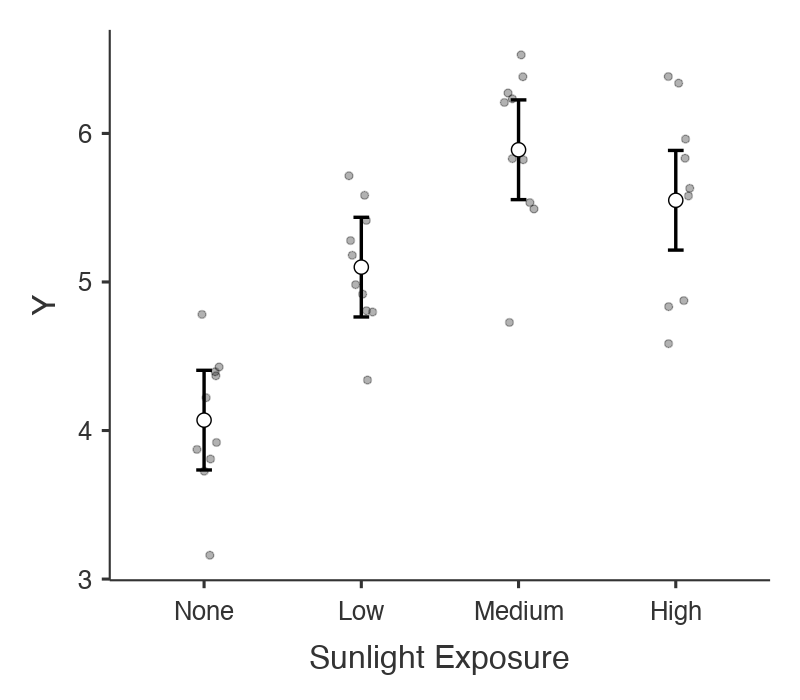

| Post Hoc Analysis - Sunlight Exposure Comparison Sunlight Exposure | Post Hoc Analysis - Sunlight Exposure Comparison Sunlight Exposure | Post Hoc Analysis - Sunlight Exposure Comparison | Post Hoc Analysis - Sunlight Exposure Comparison | Post Hoc Analysis - Sunlight Exposure Comparison Sunlight Exposure | Post Hoc Analysis - Sunlight Exposure Comparison Sunlight Exposure | Post Hoc Analysis - Sunlight Exposure Mean Difference | Post Hoc Analysis - Sunlight Exposure Mean Difference | Post Hoc Analysis - Sunlight Exposure SE | Post Hoc Analysis - Sunlight Exposure SE | Post Hoc Analysis - Sunlight Exposure df | Post Hoc Analysis - Sunlight Exposure df | Post Hoc Analysis - Sunlight Exposure t | Post Hoc Analysis - Sunlight Exposure t | Post Hoc Analysis - Sunlight Exposure p <sub>tukey</sub> | Post Hoc Analysis - Sunlight Exposure p <sub>tukey</sub> | Post Hoc Analysis - Sunlight Exposure p <sub>bonferroni</sub> | Post Hoc Analysis - Sunlight Exposure p <sub>bonferroni</sub> |
| --- | --- | --- | --- | --- | --- | --- | --- | --- | --- | --- | --- | --- | --- | --- | --- | --- | --- |
| None |  | - |  | Low |  | -1.030 |  | 0.233 |  | 32.0 |  | -4.42 |  | < .001 |  | < .001 |  |
|  |  | - |  | Medium |  | -1.820 |  | 0.233 |  | 32.0 |  | -7.81 |  | < .001 |  | < .001 |  |
|  |  | - |  | High |  | -1.480 |  | 0.233 |  | 32.0 |  | -6.35 |  | < .001 |  | < .001 |  |
| Low |  | - |  | Medium |  | -0.790 |  | 0.233 |  | 32.0 |  | -3.39 |  | 0.010 |  | 0.011 |  |
|  |  | - |  | High |  | -0.450 |  | 0.233 |  | 32.0 |  | -1.93 |  | 0.235 |  | 0.374 |  |
| Medium |  | - |  | High |  | 0.340 |  | 0.233 |  | 32.0 |  | 1.46 |  | 0.473 |  | 0.925 |  |